# 利率课程的脚本

张剑

3/11/2020

### 介绍如果安装和调用包

### 介绍如何计算NPV和IRR

### 简单展示画图——非完美版

#### 1. R或python之所以强大是应为包多，包多干的事就多。安装和调用包非常简单，在Rstudio里直接使用右边的Packages对包进行管理，用鼠标就能完成。

#### 使用代码安装install.packages(‘包的名字’)，不过我还是建议在Rstudio里直接点击安装。

#### 我们先安装一个现代R里最重要的一个套包，安装前请同学们调整好自己tools菜单，option选项里安装镜像站点的位置。

#### 调用包也非常简单，直接使用library()加包的名字，每次运行脚本时都需要把重要的包调用，首当其冲的肯定是tidyverse包

```r
#install.packages("tidyverse")
library(tidyverse)
```

### 接下来我们可以安装一个和我们接下来课程相关的金融包,代码前我加了一个“#”代表这条被注释了，大家可以用快捷键ctrl+shift+c进行注释或取消注释

```r
#install.packages("jrvFinance")
library(jrvFinance)
```

### 接下来先给大家展示一下jrvFinance包的简单用法,计算一系列现金流的PV，计算一个5年的现金流，贴现率为0.05，现金流分别为100,200,400，300,200

```r
library(jrvFinance) #先调入包
# 我们现在只做最基本的演示，其他包可以不用调入
pv <- npv(cf = c(100,200,400,300,200),rate =0.05,immediate.start=T ) ## 注意最后这个参数，上课是讲一下
paste('我们要计算的现值是:',pv)
```

```
## [1] "我们要计算的现值是: 1076.97975637723"
```

### 如果要计算IRR，也可以使用jrvFinance这个包，同样假设一系列现金流，0期支付200，后续每年回报80，持续4年，问这一组现金流的IRR是多少？

```r
library(jrvFinance) #如果你前面一个框框里调入了jrvFinance，也没有必要再次调入了
irr <- irr(cf=c(-200,80,80,80,80))
paste("我们要计算的IRR是：",irr)
```

```
## [1] "我们要计算的IRR是： 0.218622696098342"
```

```r
#嗯，确实非常简单
```

### 如果不用包，如何计算npv？

#### 下面直接写一下，按照公式很简单的也能得到，我们将使用tribble函数建立一个DataFrame（数据框）后面有机会和大家详细讲一下数据框和所谓的tidy data。这里的语法大家可能有点困惑，不过熟悉以后就会觉得非常直观。

```r
library(tidyverse)

# 我们使用tribble函数
cf <- tribble(~Year,~cash_flow,
              1,100,
              2,300,
              3,200,
              4,1000)
cf
```

```
## # A tibble: 4 x 2
##    Year cash_flow
##   <dbl>     <dbl>
## 1     1       100
## 2     2       300
## 3     3       200
## 4     4      1000
```

```r
# 给定贴现率r=0.03
r <- 0.03
npv <- cf %>%
  mutate(pv = cash_flow/(1+r)^Year) %>%
  select(pv) %>% sum()
paste("我们要求的npv是:",npv)
```

```
## [1] "我们要求的npv是: 1451.38153116722"
```

### 接下来把几个利率的图的代码和源文件也给大家，我这个也并非很好的画图展示方法，抛砖引玉大家可以研究。

```r
require(readr,tidyverse,anytime,ggthemes)
library(tidyverse)
setwd("~/我的坚果云/2020年MOOC")
readr::guess_encoding("data.csv")
```

```
## # A tibble: 4 x 2
##   encoding confidence
##   <chr>         <dbl>
## 1 GB18030        1
## 2 EUC-JP         0.67
## 3 Big5           0.54
## 4 EUC-KR         0.45
```

```r
data <- read_csv("data.csv",locale = locale(encoding = "GB18030"))
data <-data[-1,]
str(data)
```

```
## Classes 'tbl_df', 'tbl' and 'data.frame':    297 obs. of  8 variables:
##  $ 指标名称                  : chr  "2019-01" "2019-01" "2019-01" "2019-01" ...
##  $ 贷款市场报价利率(LPR):1年 : chr  "4.3100" "4.3100" "4.3100" "4.3100" ...
##  $ 贷款市场报价利率(LPR):5年 : chr  NA NA NA NA ...
##  $ SHIBOR:隔夜               : chr  "2.3000" "1.9680" "1.6490" "1.4470" ...
##  $ SHIBOR:1周                : chr  "2.6340" "2.5470" "2.5630" "2.4750" ...
##  $ 国债到期收益率:10年       : chr  "3.2042" "3.1517" "3.1316" "3.1509" ...
##  $ 企业债到期收益率(AA):10年 : chr  "5.3754" "5.3291" "5.3166" "5.3056" ...
##  $ 企业债到期收益率(AAA):10年: chr  "4.3120" "4.2550" "4.2369" "4.2187" ...
```

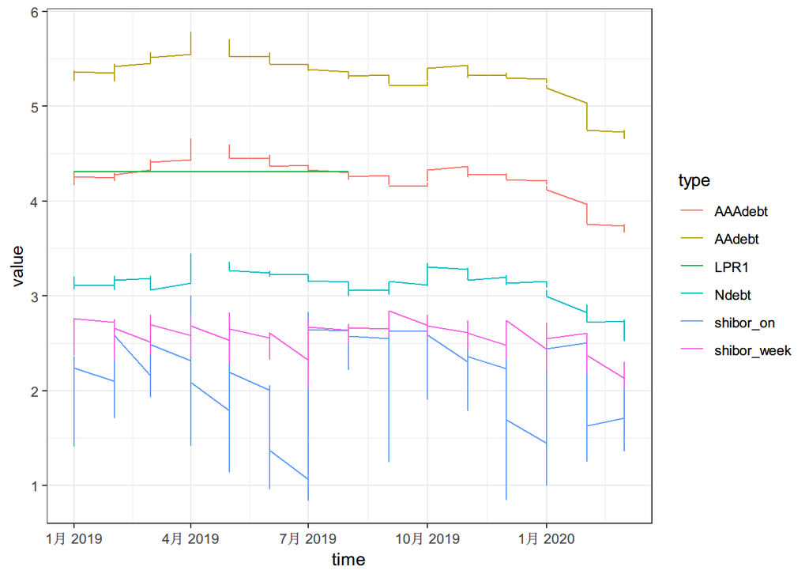

```r
data <- data %>%
  rename(time = `指标名称`) %>%
  mutate(time = anytime::anytime(time),LPR1 = as.numeric(`贷款市场报价利率(LPR):1年`),
         LPR1 = as.numeric(`贷款市场报价利率(LPR):1年`),shibor_on = as.numeric(`SHIBOR:隔夜`),shibor_week = as.numeric(`SHIBOR:1周`),Ndebt=as.numeric(`国债到期收益率:10年`),AAdebt=as.numeric(`企业债到期收益率(AA):10年`),AAAdebt = as.numeric(`企业债到期收益率(AAA):10年`),) %>%
  filter(!is.na(time) ) %>%
  select(time,shibor_on ,shibor_week,Ndebt,AAdebt,AAAdebt,LPR1) %>%
  gather(key='type',value = 'value',-time)


ggplot(data)+
  geom_line(mapping = aes(x=time, y = value,color=type))+
  theme_bw()
```